# PA1_template.Rmd

Gabor Szaraz

9/13/2018

# Loading and preprocessing the dataset

Assuming that the dataset is in the same directory as our document, here is the code that loads it, and displays some portion data:

```r
#-Read in whole dataset
activity_original <- read.csv('activity.csv', header = T)  ##read in file
head(activity_original) ##check
```

```
##   steps       date interval
## 1    NA 2012-10-01        0
## 2    NA 2012-10-01        5
## 3    NA 2012-10-01       10
## 4    NA 2012-10-01       15
## 5    NA 2012-10-01       20
## 6    NA 2012-10-01       25
```

After loading, we create new dataset, removing rows that contain NA (missing) values.

```r
#-Remove NAs form dataset
activity_completecases_only <-activity_original[complete.cases(activity_original),] ##get only completed cases
head(activity_completecases_only) ##check
```

```
##     steps       date interval
## 289     0 2012-10-02        0
## 290     0 2012-10-02        5
## 291     0 2012-10-02       10
## 292     0 2012-10-02       15
## 293     0 2012-10-02       20
## 294     0 2012-10-02       25
```

# Average total number of steps per day

### Histogram of total steps per day

First, let’s see the histogram about distribution of total steps per day.  
We use “NA removed” dataset, and group by date, then sum up steps per day.

```r
library(dplyr)
steps_by_day <- activity_completecases_only %>% group_by(date=date) %>% summarise(steps=sum(steps)) ##group by date, sum of steps per day
```

The result aggregate set is exactly what we would like to depict by histogram.

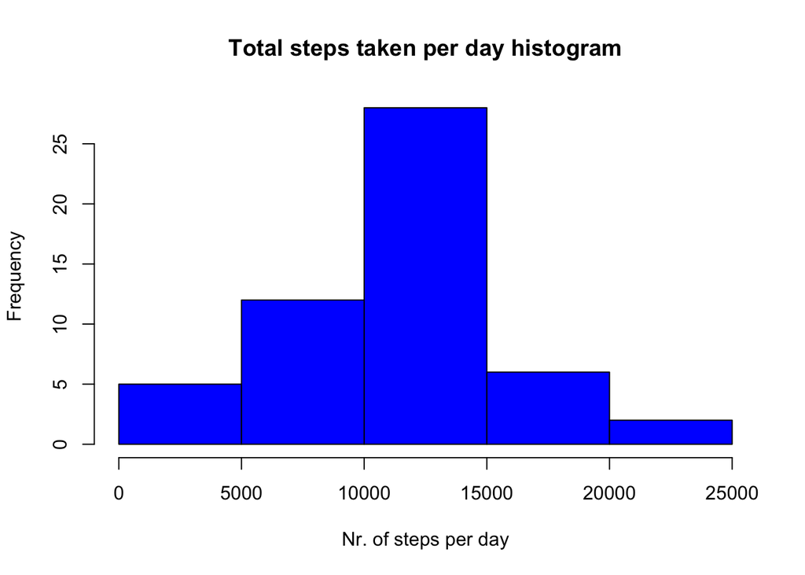

```r
#-Histogram: total number of steps taken each day
hist(steps_by_day$steps, main = "Total steps taken per day histogram", xlab = "Nr. of steps per day", col="blue") ##plot histogram
```

### Mean and median of total steps taken per day

We calculate mean and median for the steps per day dataset.

```r
#-Mean and median of daily steps
mean_of_daily_steps<-mean(steps_by_day$steps)
median_of_daily_steps<-median(steps_by_day$steps)
```

**As we calculated, mean of total steps per day is 10766.1886792453 and median is 10765.**

# Daily activity pattern

### Time series plot for intervals

For time series plot based on intervals, we now group the “NA removed” dataset by intervals, and summarize each interval by calculating mean value.

```r
#-Steps per interval
steps_by_interval <- activity_completecases_only %>% group_by(interval=interval) %>% summarise(avg_steps=mean(steps)) ##group by interval, avg of daily steps per interval
```

Then we plot the result.

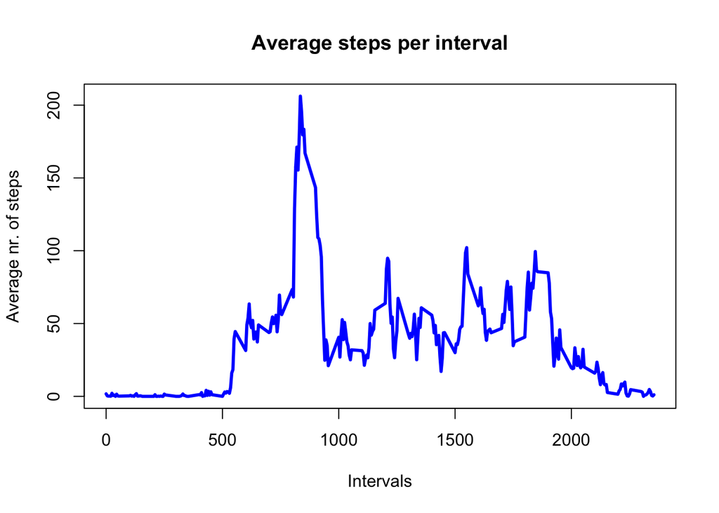

```r
plot(steps_by_interval$interval, steps_by_interval$avg_steps, type="l", col="blue", main = "Average steps per interval", xlab = "Intervals", ylab = "Average nr. of steps", lwd=3) ##plot avg steps per interval
```

### Interval for maximum value of averaged steps

First, we select maximum interval value, then the interval in which it resides.

```r
#-Maximum of average steps per interval, and interval it belongs to
max_avg_steps_per_interval<-max(steps_by_interval$avg_steps) ##max from avg steps per interval
max_avg_steps_interval <- steps_by_interval[steps_by_interval$avg_steps==max_avg_steps_per_interval,]$interval ##interval to which avg step above belongs
```

**In interval resolution, maximum number of steps was 206.169811320755, in interval 835.**

# Imputing missing values

### Number of missing values

We need to see how many missing values are in our original dataset.

```r
#-Total nr of missing values in dataset
rows_with_NA<-length(which(is.na(activity_original))) ##NAs in dataset
```

**There are 2304 missing values which will be subject of imputing.**

*As for imputing strategy, we use the appropriate interval’s average step number for every missing one.*

### Filling in missing values

We clone the original dataset. Then, in the new one, for each row’s step field:

- We evaluate whether actual value introduced is NA or not
- If yes, then we look up average step number for appropriate interval, and insert it into the place of NA value
- Last, but not least, we check some sample from the new, imputed dataset

```r
#-Replace steps NAs with appropriate interval mean
activity_imputed<-activity_original ##clone original dataset
for (i in 1:nrow(activity_imputed)) {
  ifelse(is.na(activity_imputed[i,]$steps),activity_imputed[i,]$steps<-steps_by_interval[steps_by_interval$interval==activity_imputed[i,]$interval,]$avg_steps,NA) ##replace
}
head(activity_imputed) ##check
```

```
##       steps       date interval
## 1 1.7169811 2012-10-01        0
## 2 0.3396226 2012-10-01        5
## 3 0.1320755 2012-10-01       10
## 4 0.1509434 2012-10-01       15
## 5 0.0754717 2012-10-01       20
## 6 2.0943396 2012-10-01       25
```

Let’s calculate and plot our histogram about daily totals again.

```r
steps_by_day_imputed <- activity_imputed %>% group_by(date=date) %>% summarise(steps=sum(steps)) ##group by date, sum of daily steps per day
```

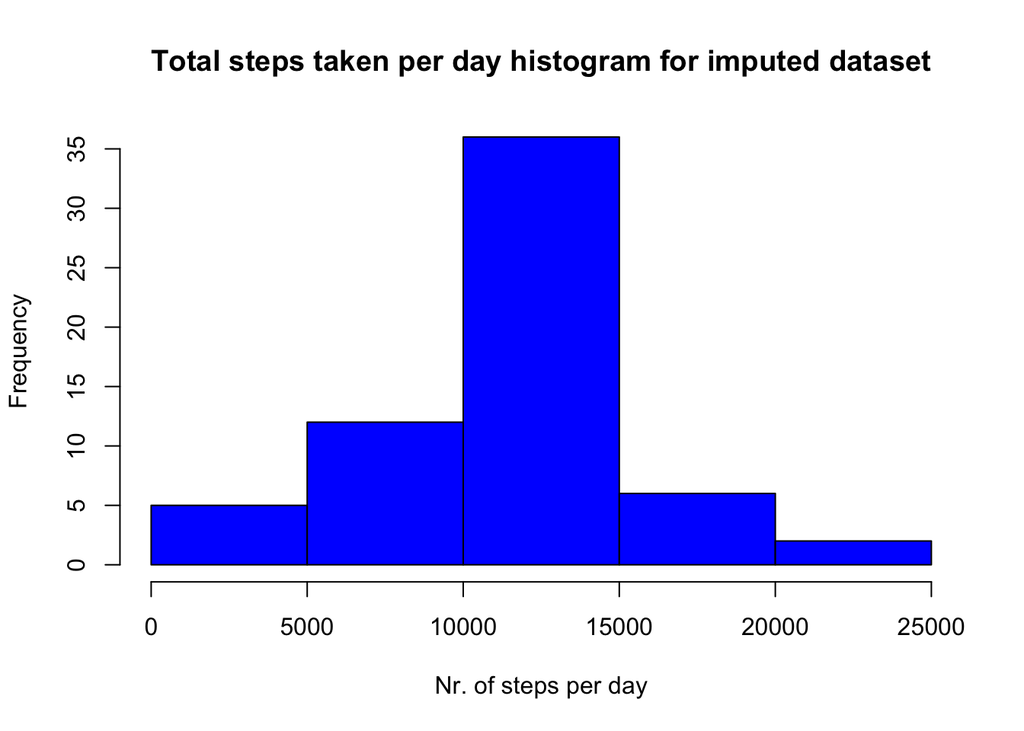

```r
#-Histogram: total number of steps taken each day
hist(steps_by_day_imputed$steps, main = "Total steps taken per day histogram for imputed dataset", xlab = "Nr. of steps per day", col="blue") ##plot histogram
```

It seems not so much of a change. What about mean and median we calculated earlier? We do the same for the imputed dataset.

```r
#-Calculate mean and median for imputed dataset
mean_of_daily_steps_imputed<-mean(steps_by_day_imputed$steps)
median_of_daily_steps_imputed<-median(steps_by_day_imputed$steps)
```

**As we calculated, mean of total steps per day is 10766.1886792453 and median is 10766.1886792453.**

**While mean is the same for the original and imputed datasets, median differs, although the difference is very slight.**

# Activity pattern difference between weekdays and weekends

### Extending dataset with day indicator

First, we insert a new column to our imputed dataset, to indicate whether given date is weekday, or weekend. Second, we fill the new variable for every observation as weekday/weekend, based on the date.

```r
#-New variable to indicate weekday/weekend in dataset
activity_imputed$dayfactor<-"" ##new column, empty
#-Replace "" with "weekday"/"weekend"
for (i in 1:nrow(activity_imputed)) {
  ifelse(weekdays(as.Date(activity_imputed[i,]$date)) %in% c("Saturday","Sunday"), activity_imputed[i,]$dayfactor<-"weekend", activity_imputed[i,]$dayfactor<-"weekday") ##replace
}
activity_imputed$dayfactor<-as.factor(activity_imputed$dayfactor)
```

### Comparison plot for weekends and weekdays about steps per interval

For this, we need to group our extended dataset by interval AND our newly introduced day indicator.

```r
steps_by_interval_by_dayfactor <- activity_imputed %>% group_by(interval=interval, dayfactor=dayfactor) %>% summarise(avg_steps=mean(steps)) ##group by interval AND dayfactor, avg of daily steps per interval
```

Then we can easily plot the result.

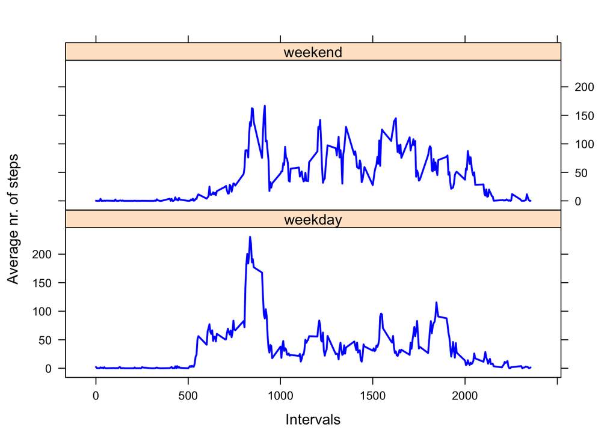

```r
#-Plot for weekend/weekday
library(lattice)
xyplot(avg_steps~interval|dayfactor, data=steps_by_interval_by_dayfactor, type="l", col="blue", lwd=2, layout=c(1,2), xlab = "Intervals", ylab = "Average nr. of steps") #plot w/ lattice
```

**At first sight, we can see that there are more activities on the weekends.**